# R Notebook

#### Objectif TD : Représentation euclidienne des données

> Rappel :

> **ACP** : Permet de faire un changement de base pour concentrer les données autour des axes

# Exercice 1

```r
notes <- read.table("donnees/notes.txt", header=T)
rownames(notes) <- c()
dim(notes)
```

```
[1] 9 5
```

```r
head(notes)
```

|  | math | scie | fran | lati | d.m |
| --- | --- | --- | --- | --- | --- |
| 1 | 6.0 | 6.0 | 5.0 | 5.5 | 8 |
| 2 | 8.0 | 8.0 | 8.0 | 8.0 | 9 |
| 3 | 6.0 | 7.0 | 11.0 | 9.5 | 11 |
| 4 | 14.5 | 14.5 | 15.5 | 15.0 | 8 |
| 5 | 14.0 | 14.0 | 12.0 | 12.5 | 10 |
| 6 | 11.0 | 10.0 | 5.5 | 7.0 | 13 |

Permet de représenter les individus par les valeurs des variables 1 et 2, et de les identifier en fonction du nom renseigné dans le data.frame :

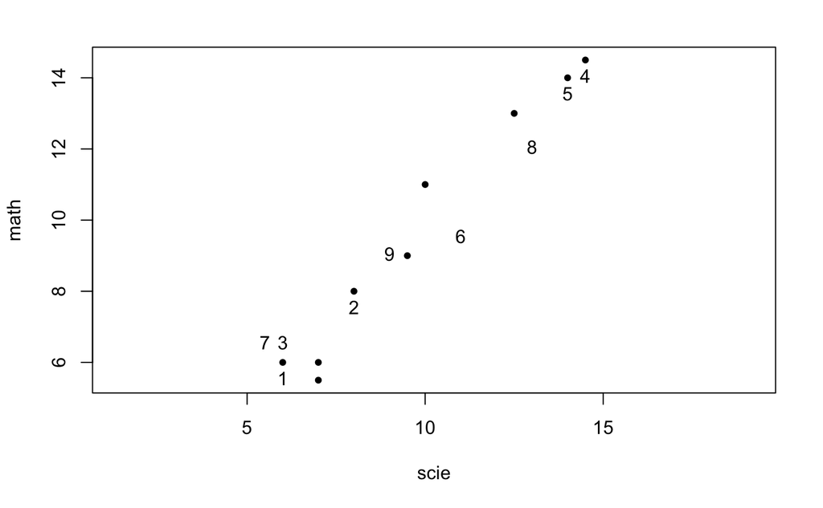

```r
plot(math~scie, data=notes, pch=20, asp=1)
text(notes[,c("math","scie")], row.names(notes), pos=1)
```

Si les données sont simplement définies par une matrice et non un data.frame, on pourra utiliser les instructions suivantes : `plot(notes[,c(i,j)], pch=20, asp=1)` `text(notes[,c(i,j)], row.names(notes), pos=1)`

## Analyse des données

On sait qu;il y a 5 matières : math, science, francais, latin et arts.

### Répartions des notes

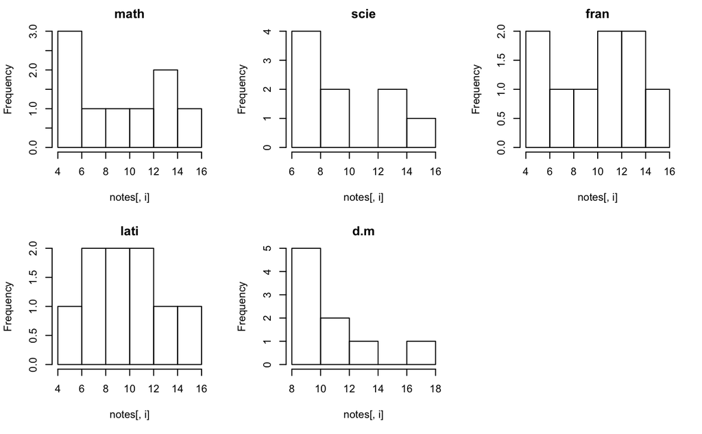

```r
def.par <- par(no.readonly = T)
title<-
par(mfrow = c(2, 3))
for (i in 1:5) {
  hist(notes[, i], main = names(notes)[i])
}
par(def.par)
```

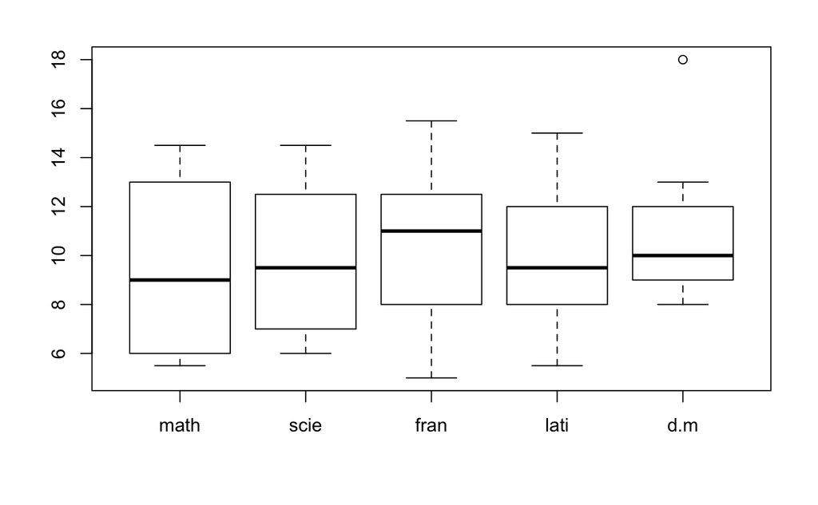

```r
boxplot(notes)
```

### Peut-on rapprocher certaines matières les unes des autres ?

```r
cor(notes)
```

```
           math        scie       fran       lati         d.m
math 1.00000000 0.982535729 0.22673193 0.50814398 0.011183835
scie 0.98253573 1.000000000 0.39669324 0.65153051 0.006309933
fran 0.22673193 0.396693238 1.00000000 0.95120575 0.038035989
lati 0.50814398 0.651530514 0.95120575 1.00000000 0.080500057
d.m  0.01118384 0.006309933 0.03803599 0.08050006 1.000000000
```

Ains les notes de :

- Mathématiques et de Sciences sont très corrélées
- Francais et de latin sont très corrélées
- L’art semble etre une discipline à part (peu de corrélation avec les autres matières)

## Analyse des groupes d’élèves

### Représenter les élèves en fonction de leurs résultats dans les matières scientifiques

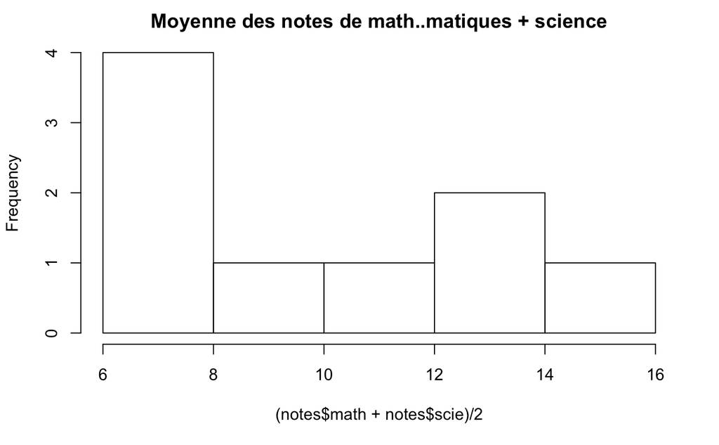

```r
hist((notes$math+notes$scie)/2, main = "Moyenne des notes de mathématiques + science")
```

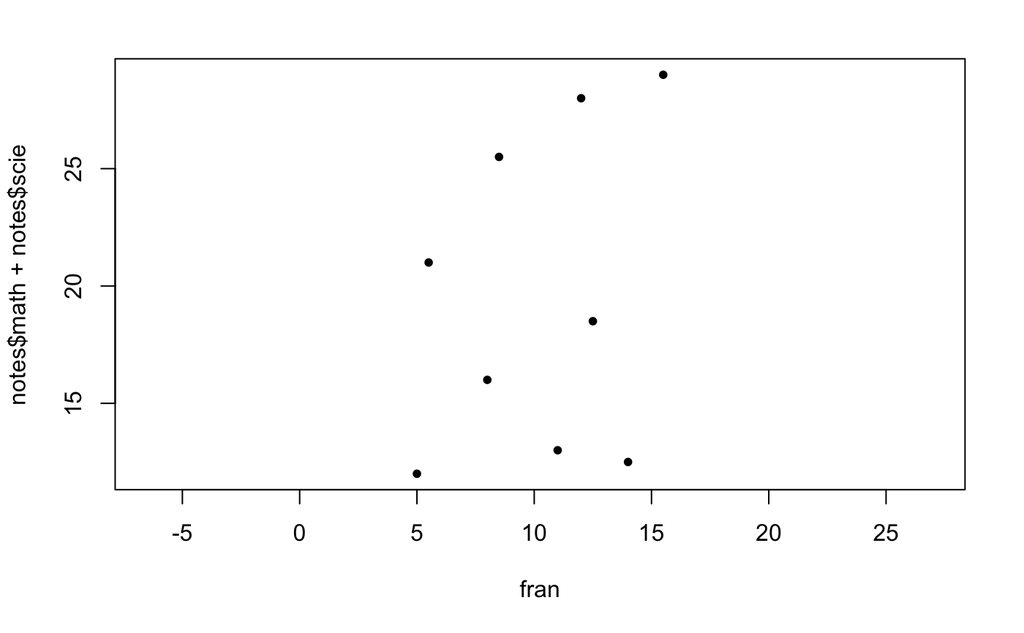

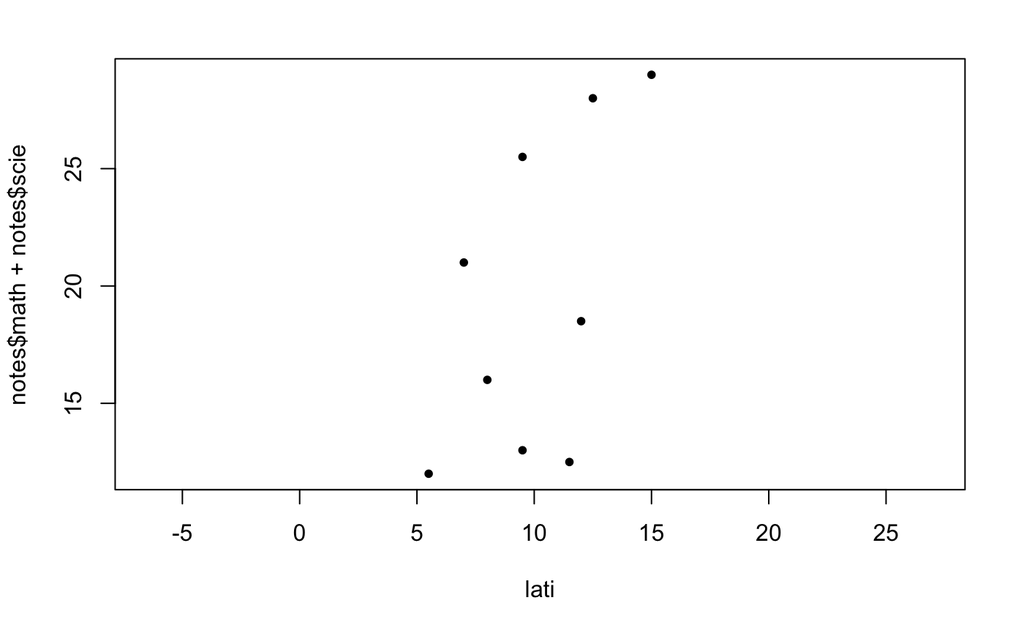

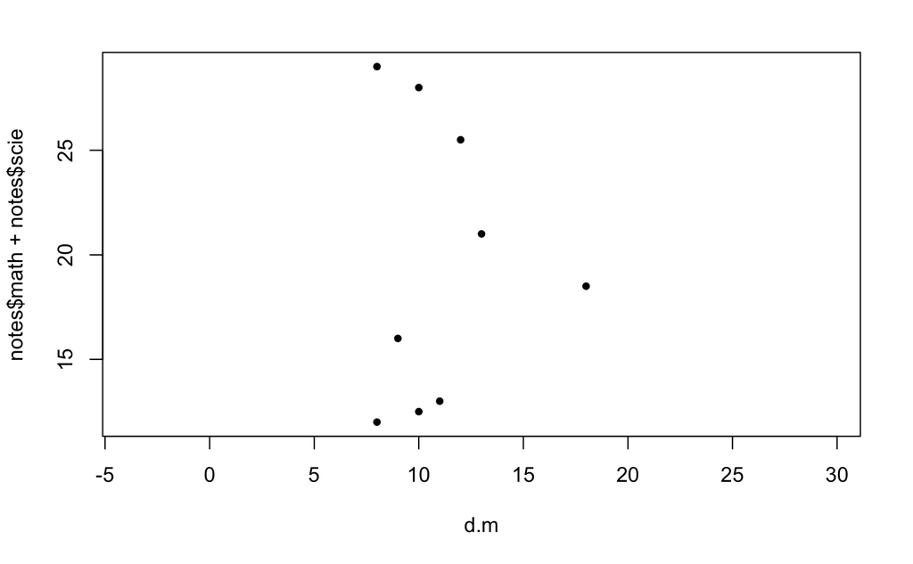

```r
plot(notes$math+notes$scie~., data=notes, pch=20, asp=1)
```

# Projection et qualité de représentation

Il s’agit du principe principal de l’ACP.

> **Rappel**

> Base (libre + génératrice) : Nombre de vecteurs non-colinéraire

> $\rightarrow$ Pivot de gauss

> Si on a A une base, et qu’on veut projeter une matrice X dans cette base on a $X' = X * (A^{-1})^T$

> Orthogonale : produit scalaire de chaque colonne deux à deux = 0

> Si A orthonormé alors $A = (A^{-1})^T$

```r
source("fonctions/distXY.r")
source("fonctions/is.passage.r")
source("fonctions/MatP.R")
```

```r
head(notes)
```

|  | math | scie | fran | lati | d.m |
| --- | --- | --- | --- | --- | --- |
| jean | 6.0 | 6.0 | 5.0 | 5.5 | 8 |
| alin | 8.0 | 8.0 | 8.0 | 8.0 | 9 |
| anni | 6.0 | 7.0 | 11.0 | 9.5 | 11 |
| moni | 14.5 | 14.5 | 15.5 | 15.0 | 8 |
| didi | 14.0 | 14.0 | 12.0 | 12.5 | 10 |
| andr | 11.0 | 10.0 | 5.5 | 7.0 | 13 |

```r
notesProj <- data.matrix(notes)%*%t(ginv(A1))
notesProj
```

```
     [,1] [,2] [,3] [,4] [,5]
jean 12.0 10.5  0.0 -0.5    8
alin 16.0 16.0  0.0  0.0    9
anni 13.0 20.5 -1.0  1.5   11
moni 29.0 30.5  0.0  0.5    8
didi 28.0 24.5  0.0 -0.5   10
andr 21.0 12.5  1.0 -1.5   13
pier 12.5 25.5 -1.5  2.5   10
brig 25.5 18.0  0.5 -1.0   12
evel 18.5 24.5 -0.5  0.5   18
```

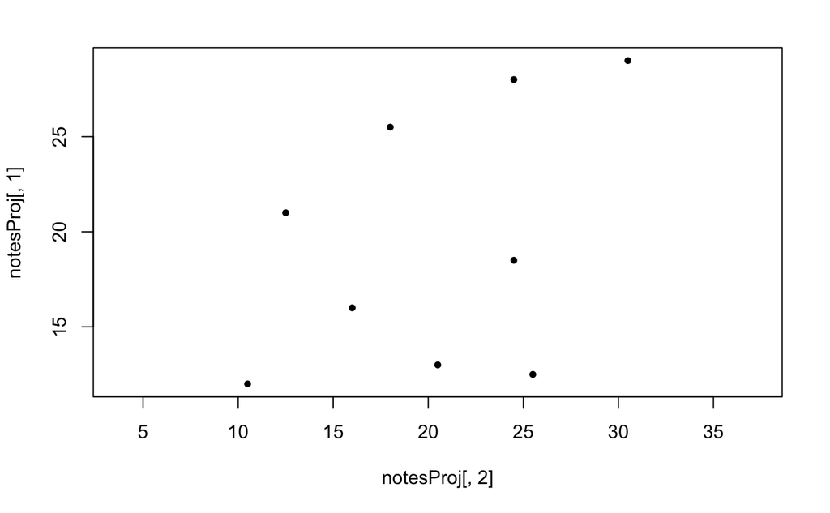

```r
plot(notesProj[,1]~notesProj[,2], pch=20, asp=1)
```

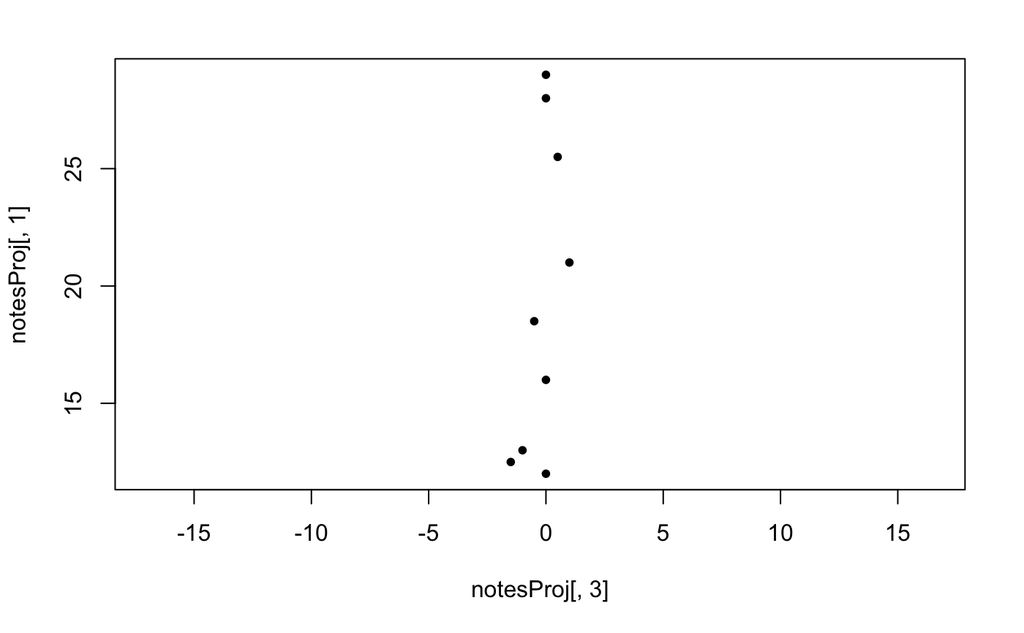

```r
plot(notesProj[,1]~notesProj[,3], pch=20, asp=1)
```

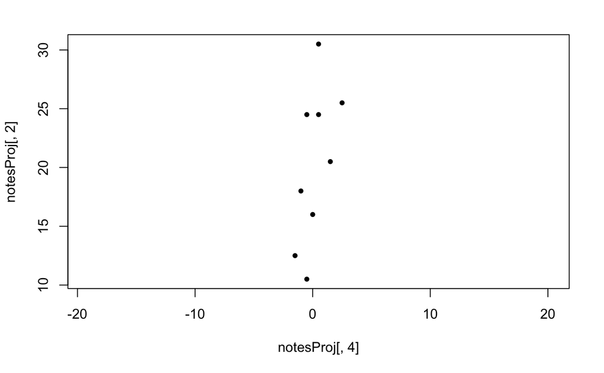

```r
plot(notesProj[,2]~notesProj[,4], pch=20, asp=1)
```

On en conclu que cette projection est mauvaise et qu’on perd meme des informations par rapport à la base principale.

```r
notesProj2 <- data.matrix(notes)%*%t(ginv(B1))
notesProj2
```

```
          [,1]      [,2]          [,3]          [,4] [,5]
jean  8.485281  7.424621 -6.106227e-16 -3.535534e-01    8
alin 11.313708 11.313708  3.944305e-31  8.881784e-16    9
anni  9.192388 14.495689 -7.071068e-01  1.060660e+00   11
moni 20.506097 21.566757 -1.665335e-16  3.535534e-01    8
didi 19.798990 17.324116  9.436896e-16 -3.535534e-01   10
andr 14.849242  8.838835  7.071068e-01 -1.060660e+00   13
pier  8.838835 18.031223 -1.060660e+00  1.767767e+00   10
brig 18.031223 12.727922  3.535534e-01 -7.071068e-01   12
evel 13.081475 17.324116 -3.535534e-01  3.535534e-01   18
```

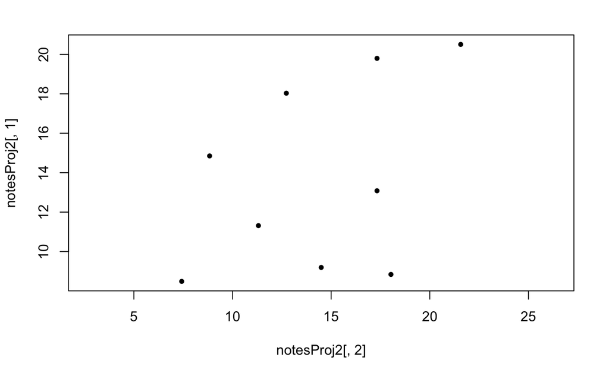

```r
plot(notesProj2[,1]~notesProj2[,2], pch=20, asp=1)
```

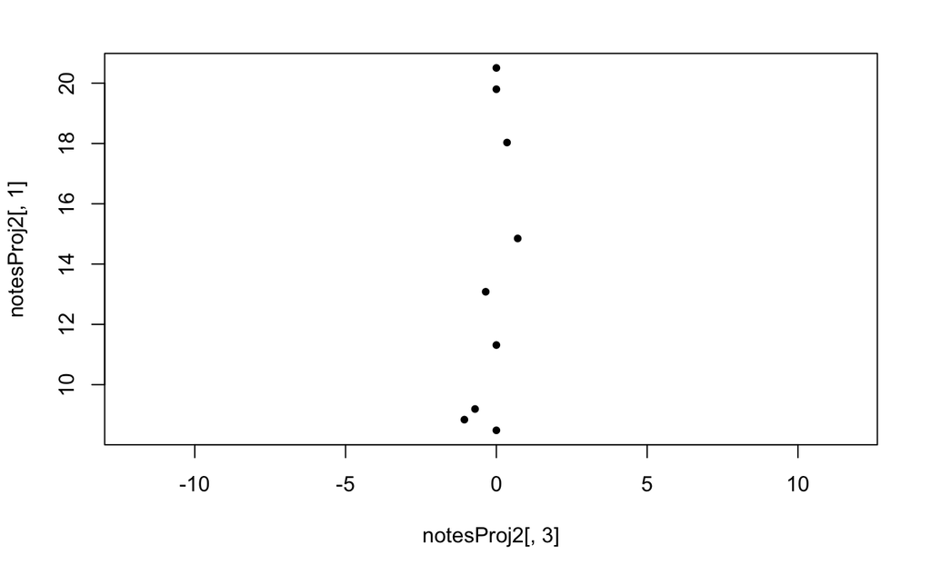

```r
plot(notesProj2[,1]~notesProj2[,3], pch=20, asp=1)
```

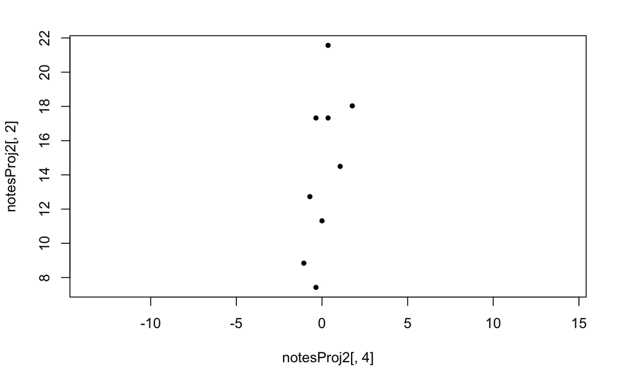

```r
plot(notesProj2[,2]~notesProj2[,4], pch=20, asp=1)
```

Ca ne change pas vraiment. Ici 3 et 4 ne sont pas porteur d’informations, la variance est trop faible

```r
notesProj3 <- data.matrix(notes)%*%t(ginv(B2))
notesProj3
```

```
          [,1]      [,2]          [,3]          [,4] [,5]
jean  7.778175  8.131728  7.071068e-01  3.535534e-01    8
alin 11.313708 11.313708 -8.881784e-16 -8.881784e-16    9
anni 12.020815 11.667262 -3.535534e+00 -1.767767e+00   11
moni 21.213203 20.859650 -7.071068e-01 -3.535534e-01    8
didi 18.384776 18.738330  1.414214e+00  1.060660e+00   10
andr 11.667262 12.020815  3.889087e+00  2.121320e+00   13
pier 13.788582 13.081475 -6.010408e+00 -3.181981e+00   10
brig 15.202796 15.556349  3.181981e+00  2.121320e+00   12
evel 15.202796 15.202796 -2.474874e+00 -1.767767e+00   18
```

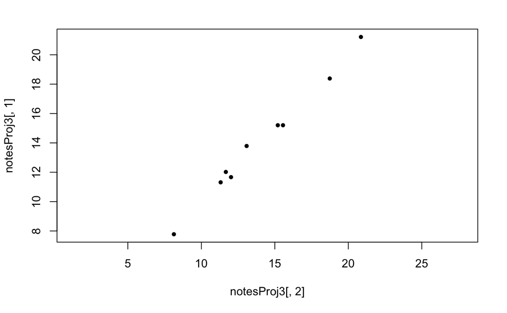

```r
plot(notesProj3[,1]~notesProj3[,2], pch=20, asp=1)
```

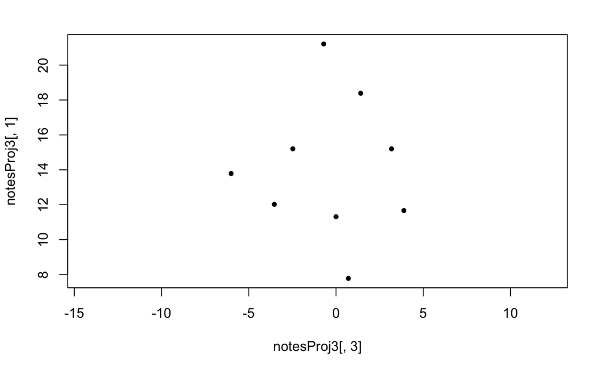

```r
plot(notesProj3[,1]~notesProj3[,3], pch=20, asp=1)
```

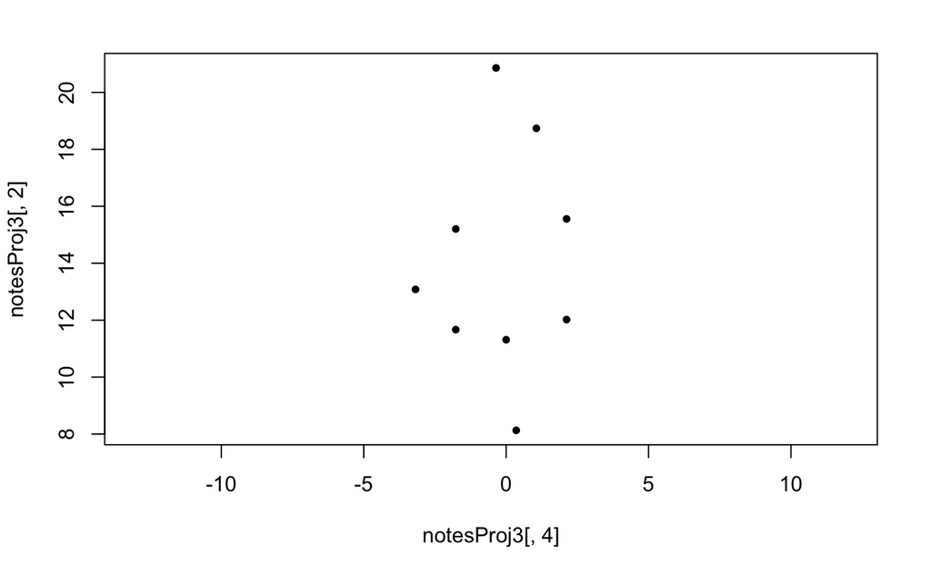

```r
plot(notesProj3[,2]~notesProj3[,4], pch=20, asp=1)
```

# Choix d’une représentation

On définit la qualité de la représentation selon un axe comme étant la quantité d’inertie expliquée par cet axe.

> **Inertie**

> $I = (1/n)*\sum_{i} d^2(x_i,\mu) = (1/n)\sum_{i}\sum_{j} (x_j^i - \mu_j)^2$

> C’est égale à la trace de la matrice de covariance

#### Quelle est la quantité d’inertie du nuage de points expliquée par chacun des axes, si l’on considère la base canonique de R5 ? Quelle est la quantité d’inertie totale du nuage de points ?

```r
sum(diag(cov(notes)))
```

```
[1] 55.09722
```

```r
sum(diag(cov(notesProj)))
```

```
[1] 100.4444
```

```r
sum(diag(cov(notesProj2)))
```

```
[1] 55.09722
```

```r
sum(diag(cov(notesProj3)))
```

```
[1] 55.09722
```

Il ne faut pas que l’inertie entre la matrice de base et celle de la projection change. Sinon cela indique qu’on perd de l’information sur la repartition. Ici on constate que A1 le fait changer, c’est due au fait qu’elle ne soit pas orthonormé.

#### Quelle est la quantité d’inertie expliquée par les axes si l’on considère la base A1 ?

#### Qu’en est-il pour la base B1, pour la base B2 ?

#### On cherche à représenter le nuage de points dans un plan, au prix d’une perte d’information. Quels axes choisirait-on, parmi ceux définis par la base canonique, par B1, ou par B2 ? Pourquoi ? Interpréter.